# Modelando uma série temporal

SME0808-Séries Temporais

16 de novembro de 2015

- Giovani Carrara Rodrigues 7151669
- Diego Aoki 5991861
- Vitor Bonini 8065859

## 1. A série temporal

Abaixo temos o gráfico de temperaturas máximas diária em Melbourne, Australia, 1981-1990. Os dados podem ser baixados no seguinte link https://datamarket.com/data/set/2323/daily-maximum-temperatures-in-melbourne-australia-1981-1990#!ds=2323&display=line

[interactive chart not shown]

Vemos que nossa série não tem tendência, mas claramente tem sazonalidade. Portanto vamos adotar o seguinte modelo:

$X_t = S_t + Z_t$ , onde $S_t$ é componente sazonal e $Z_t$ é componente estocástica

Utilizando o modelo não paramétrico para sazonalidade temos que um estimador é dado por

$\hat{\mu}_m = \frac{1}{n} \sum\limits_{r=1}^{n}X_{r,m}$, onde $n \in (1,10)$ e $m \in (1,365)$

No código abaixo aplicamos esse estimador para sazonalidade em nossa série

```r
#lendo os dados
data = read.csv("daily-maximum-temperatures-in-me.csv",sep=",",header=T)

aux = data
for(i in 1:365)
{
  for(k in 1:9)
  {
    aux[i,2] = aux[i,2] + aux[i+(k*365),2]
  }
}
aux[,2] = aux[,2]/10
sazo = rep(aux[1:365,2],10)
```

Portando nossa sazonalidade estimada fica

```r
# criando objeto ts para sazonalidade
sazots = ts(sazo, start = c(1981,1),frequency = 365 )

# criando objeto xts para sazonalidade
sazoxts = xts(sazo, order.by = as.Date(data[,1],"%Y-%m-%d"))

# plotando sazonalidade (sazoxts)
dygraph(sazoxts, main ="Sazonalidade") %>%
    dySeries("V1", label = "Temperatura (C)")
```

[interactive chart not shown]

Estraindo a sazonalidade da série ficamos com a seguinte série só com a componente estocástica $(Z_t)$

```r
# subtraindo a sazonalidade da série
aux2 = data[,2] - sazo

# criando objeto ts da série sem subtraida pela sazonalidade
tsnosazo = ts(aux2, start = c(1981,1), frequency = 365)

# criando objeto xts da série subtraida pela sazonalidade
xtsnosazo = xts(aux2, order.by = as.Date(data[,1],"%Y-%m-%d"))

# plotando a serie subtraida pela sazonalidade
dygraph(xtsnosazo, main ="Componente Estocástica") %>%
    dySeries("V1", label = "Temperatura (C)")
```

[interactive chart not shown]

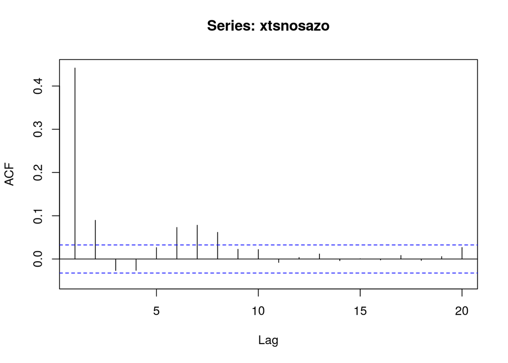

```r
Acf(xtsnosazo, lag.max=20)
```

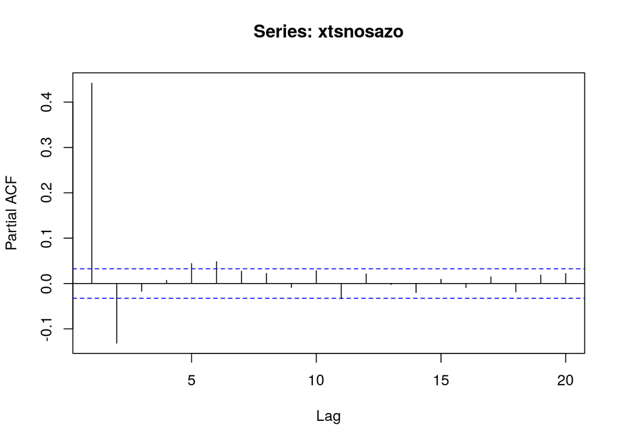

```r
Pacf(xtsnosazo, lag.max=20)
```

## 2. Escolha do Modelo

Vamos testar os seguintes modelos analisando os resíduos e depois comparar o AIC e BIC para decidir qual deles usar, onde quanto menor o valor dessas medidas, melhor o modelo.

```r
##  SERIE - SERIEAJUSTADA = RESIDUO => SERIEAJUSTADA = SERIE - RESIDUO ##

# AR(2) = ARIMA(2,0,0)
ar2 = Arima(tsnosazo, order = c(2,0,0))
ar2
```

```
## Series: tsnosazo
## ARIMA(2,0,0) with non-zero mean
##
## Coefficients:
##          ar1      ar2  intercept
##       0.5010  -0.1315    -0.0006
## s.e.  0.0164   0.0164     0.0958
##
## sigma^2 estimated as 13.32:  log likelihood=-9904.05
## AIC=19816.1   AICc=19816.11   BIC=19840.91
```

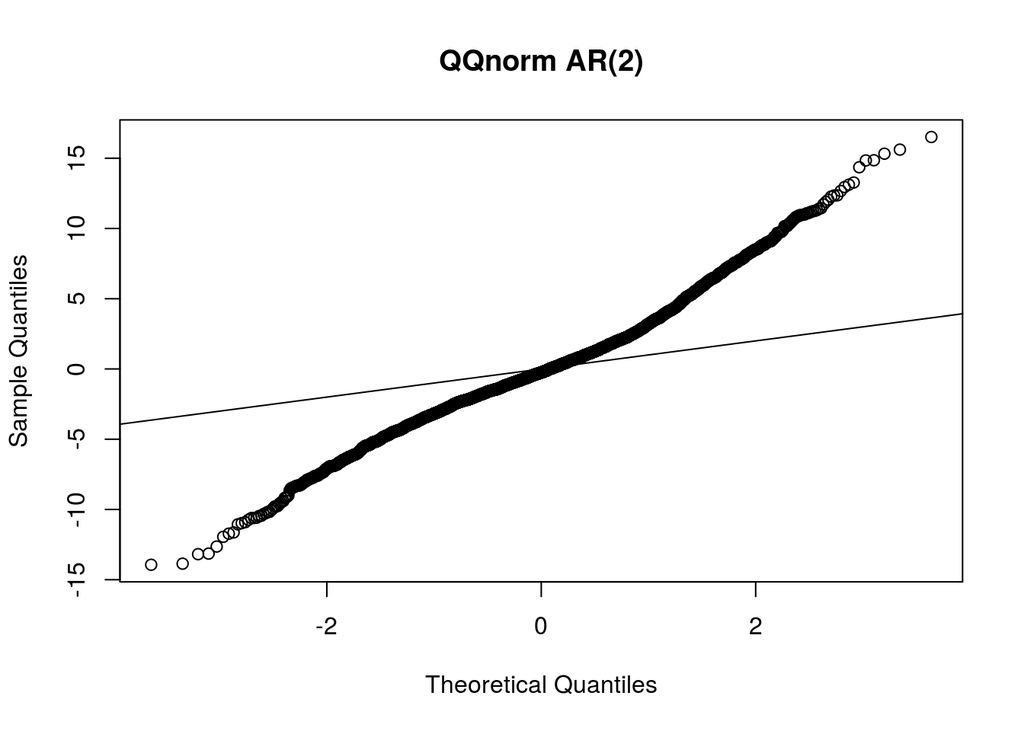

```r
# componente estocastica ajustada
fitar2 =tsnosazo - ar2$residuals
qqnorm(ar2$residuals, main ="QQnorm AR(2)")
abline(0, 1)
```

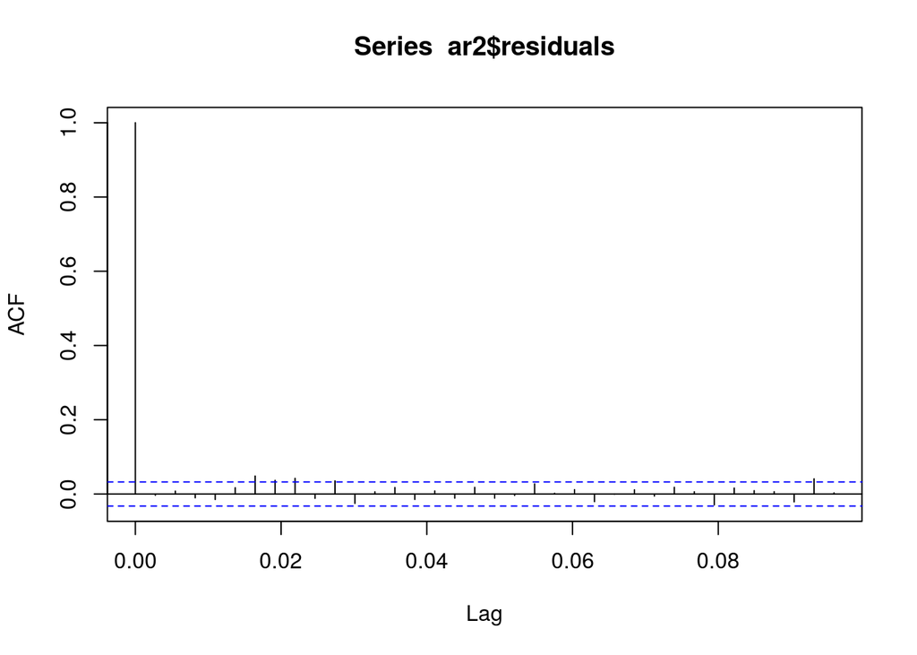

```r
# grafico autocorrelação resíduos AR(2)
acf(ar2$residuals)
```

```r
# componente estocastica mais comp. sazonal = serie ajustada
artsfit = sazots + fitar2
# residuo levando em consideração a série estimada
arres = ts2 - artsfit
# plot da série estimada e serie real
aux = as.data.frame(artsfit)
arxtsfit = xts(aux[,1], order.by = as.Date(data[,1],"%Y-%m-%d"))
tss = cbind(ts3, arxtsfit)
colnames(tss) = c("Série Original","AR(2)")
dygraph(tss, main = "AR(2)") %>%
  dyRangeSelector()
```

[interactive chart not shown]

```r
# MA(2) = ARIMA(0,0,1)
ma2 = Arima(tsnosazo, order = c(0,0,2))
ma2
```

```
## Series: tsnosazo
## ARIMA(0,0,2) with non-zero mean
##
## Coefficients:
##          ma1     ma2  intercept
##       0.4981  0.1269     0.0002
## s.e.  0.0163  0.0167     0.0982
##
## sigma^2 estimated as 13.33:  log likelihood=-9905.53
## AIC=19819.06   AICc=19819.07   BIC=19843.87
```

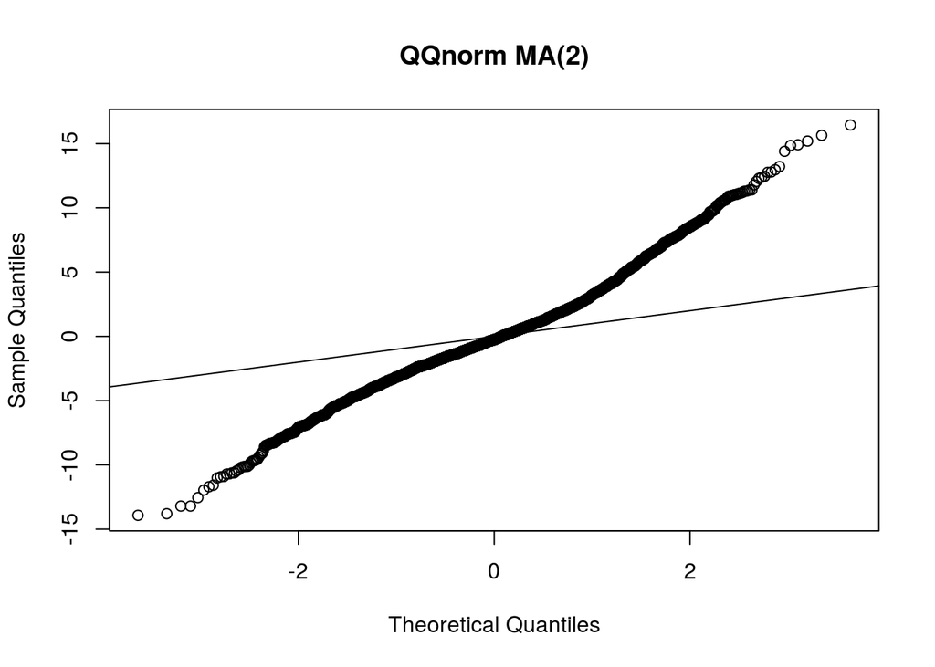

```r
# componente estocastica ajustada
fitma2 =tsnosazo - ma2$residuals
qqnorm(ma2$residuals,main ="QQnorm MA(2)")
abline(0, 1)
```

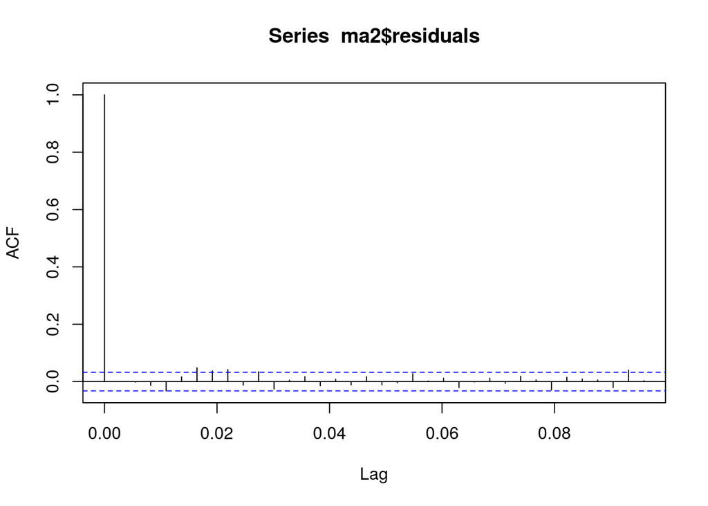

```r
# grafico autocorrelação resíduos MA(2)
acf(ma2$residuals)
```

```r
# componente estocastica mais comp. sazonal = serie ajustada
matsfit = sazots + fitma2
# residuo levando em consideração a série estimada
mares = ts2 - matsfit
# plot da série estimada e serie real
aux = as.data.frame(matsfit)
maxtsfit = xts(aux[,1], order.by = as.Date(data[,1],"%Y-%m-%d"))
tss = cbind(ts3, maxtsfit)
colnames(tss) = c("Série Original","MA(2)")
dygraph(tss, main = "MA(2)") %>%
  dyRangeSelector()
```

[interactive chart not shown]

```r
# ARMA(2,2) = ARIMA(2,0,2)
arma22 = Arima(tsnosazo, order = c(2,0,2))
arma22
```

```
## Series: tsnosazo
## ARIMA(2,0,2) with non-zero mean
##
## Coefficients:
##          ar1      ar2      ma1     ma2  intercept
##       0.5291  -0.1725  -0.0307  0.0362    -0.0007
## s.e.  0.1673   0.0547   0.1675  0.0551     0.0943
##
## sigma^2 estimated as 13.31:  log likelihood=-9903.42
## AIC=19818.84   AICc=19818.86   BIC=19856.06
```

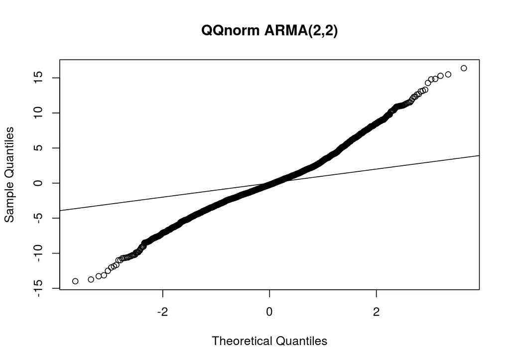

```r
# componente estocastica ajustada
fitarma22 =tsnosazo - arma22$residuals
qqnorm(arma22$residuals, main="QQnorm ARMA(2,2)")
abline(0,1)
```

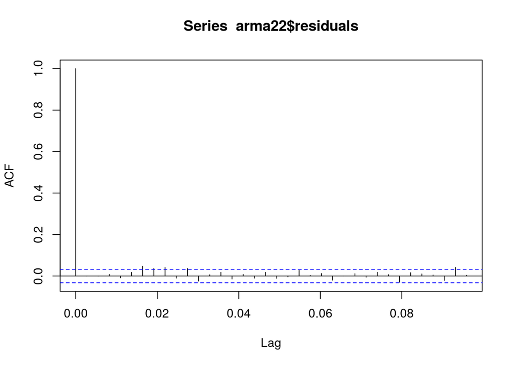

```r
# grafico autocorrelação resíduos AR(2)
acf(arma22$residuals)
```

```r
# componente estocastica mais comp. sazonal = serie ajustada
armatsfit = sazots + fitarma22
# residuo levando em consideração a série estimada
armares = ts2 - armatsfit
# plot da série estimada e serie real
aux = as.data.frame(armatsfit)
armaxtsfit = xts(aux[,1], order.by = as.Date(data[,1],"%Y-%m-%d"))
tss = cbind(ts3, armaxtsfit)
colnames(tss) = c("Série Original","ARMA(2,2)")
dygraph(tss, main = "ARMA(2,2)") %>%
  dyRangeSelector()
```

[interactive chart not shown]

```r
# ARIMA(2,1,2)
arima212 = Arima(ts2, order = c(2,1,2))
arima212
```

```
## Series: ts2
## ARIMA(2,1,2)
##
## Coefficients:
##          ar1      ar2      ma1     ma2
##       0.8216  -0.3108  -1.2657  0.3334
## s.e.  0.0811   0.0349   0.0838  0.0776
##
## sigma^2 estimated as 15.54:  log likelihood=-10184.27
## AIC=20378.54   AICc=20378.55   BIC=20409.55
```

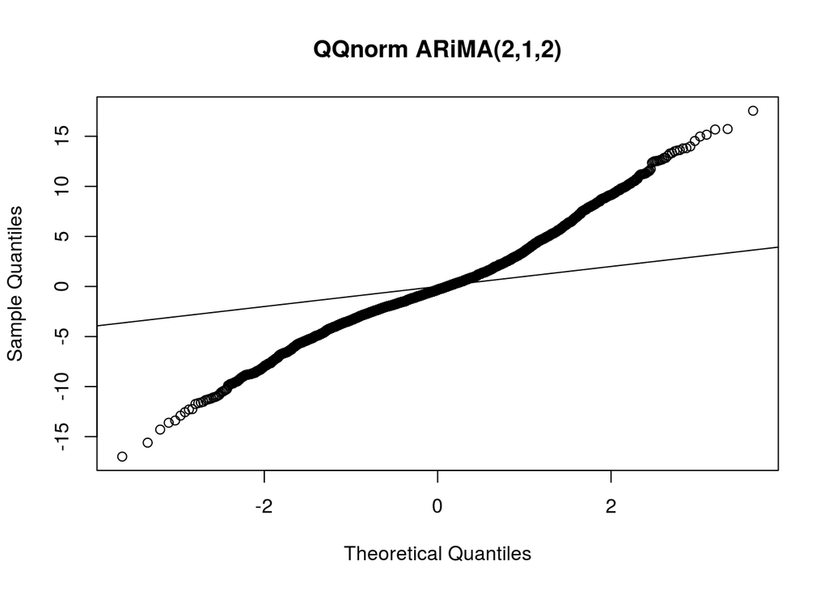

```r
# componente estocastica ajustada
fitarima212 =tsnosazo - arima212$residuals
qqnorm(arima212$residuals, main="QQnorm ARiMA(2,1,2)")
abline(0,1)
```

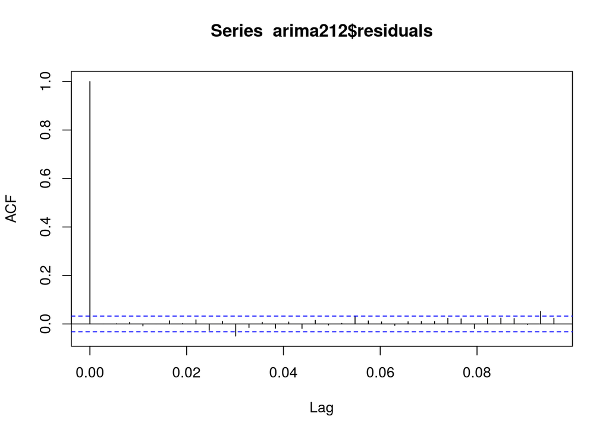

```r
# grafico autocorrelação resíduos AR(2)
acf(arima212$residuals)
```

```r
# componente estocastica mais comp. sazonal = serie ajustada
arimatsfit = sazots + fitarima212
# residuo levando em consideração a série estimada
arimares = ts2 - arimatsfit
# plot da série estimada e serie real
aux = as.data.frame(arimatsfit)
arimaxtsfit = xts(aux[,1], order.by = as.Date(data[,1],"%Y-%m-%d"))
tss = cbind(ts3, arimaxtsfit)
colnames(tss) = c("Série Original","ARIMA(2,1,2)")
dygraph(tss, main = "ARIMA(2,1,2)") %>%
  dyRangeSelector()
```

[interactive chart not shown]

```r
supertss = cbind(ts3,arxtsfit,maxtsfit,armaxtsfit,arimaxtsfit)
colnames(supertss) = c("Série Original","AR(2)","MA(2)","ARMA(2,2)","ARIMA(2,1,2)")
dygraph(supertss, main = "Todos") %>%
  dyRangeSelector()
```

[interactive chart not shown]

Todos os modelos parecem ter resíduos não normais e não correlacionados, como visto nos gráficos de auto-correlação. Contudo o melhor modelo é o AR(2), pois possui o menor AIC e BIC.

## 3. Previsão